# Bank_Marketing_TFM

#### 8.2. Red Neuronal

Dicho modelo está compuesto por una serie de capas donde se define el número de neuronas y su función de activación en cada capa.Cada neurona está compuesta por una suma ponderada de todos los valores de entrada más un valor bias. Por tanto la matriz de pesos para esa capa está compuesta de N filas/neuronas de la capa anterior x M neuronas/columnas de la capa actual.  
Las funciones de activación más típicas suele ser sigmoide donde da como resultado 0 o 1 en función del valor de entrada o una relu donde realiza un filtrado de los valores negativos.

En el siguiente bloque se define una red neuronal compuesta por:

- Una capa de entrada de 38 entradas , ya que se compone de 38 variables en el procesado del dataset.
- Una capa de normalización de datos para obtener mejores resultados.
- Dos capas ocultas, una de 64 neuronas u otra de 16
- Una capa de drop out para mejorar el rendimiento
- Por ultima la capa de salida que predicirá la clase.

Su arquitectura de red se define mediante el api de keras. Y las funciones de activación en capas intermedias suele ser Relu y en la capa final sigmoide.

Para su entrenamiento y optimización, al ser un problema de clasificación binaria, se utiliza como función de pérdida la logarítimca 'binary_crossentropy' y el algoritmo de descenso de gradiente eficiente 'adams'. Y para evaluar su calidad, se utiliza como métrica la exactitud o accuracy.

La malla de parámetros definida es:

- epochs: es el número de ves que se ejecuta el algoritmo
- batch_size: es el número de datos que tiene cada iteración de un cliclo (epoch)

En el el siguiente bloque se puede observar los detalles de la implementación.

Se concluye que el 'accuracy' no mejora con respecto a grading boosting o arbol de decisión que son los que mejor resultado hasta ahora han dado.

```python
# Implementacion de red neuronal
# Para las redes neuronales se utiliza el paquete keras & TensorFlow
# 1. Se importan las librerías necesarias: keras, Sequential, ...
#!pip install --upgrade tensorflow

from tensorflow import keras
import tensorflow as tf
from keras.models import Sequential
from keras.wrappers.scikit_learn import KerasClassifier
from keras.layers.core import Dense, Dropout, Activation
#x_train,x_test,y_train,y_test = train_test_split(x,y, random_state=42)

# 2. Definición de la arquitectura de lka red neuronal
def create_model():
  model = keras.Sequential([
    keras.layers.Flatten(input_shape=(38,)),
    tf.keras.layers.BatchNormalization(),
    keras.layers.Dense(64, activation='relu'),
    keras.layers.Dense(16, activation='relu'),
    keras.layers.Dropout(0.2),
    keras.layers.Dense(1, activation='sigmoid')
  ])
  model.compile(loss='binary_crossentropy', optimizer='adam', metrics=['accuracy'])
  return model

# 3. Se invoca la red neuronal
model_nn = KerasClassifier(build_fn=create_model, verbose=0)

# 4. Se define la malla de hiper-parámetros.
batch_size = [100, 150]
epochs = [10]
params_grid_nn = dict(batch_size=batch_size, epochs=epochs)

# 5. Entrenamiento del modelo con la malla de parámetros
nn_grid = training_model_hyperparameter(model_nn, 'roc_auc', params_grid_nn, x_train, y_train)
nn_grid.best_params_
#grid = GridSearchCV(estimator=model, param_grid=param_grid, n_jobs=-1, cv=3)

# 6. Se imprime los mejores parámetros obtenidos
print("Best: %f using %s" % (nn_grid.best_score_, nn_grid.best_params_))
```

```
Best: 0.782816 using {'batch_size': 150, 'epochs': 10}
```

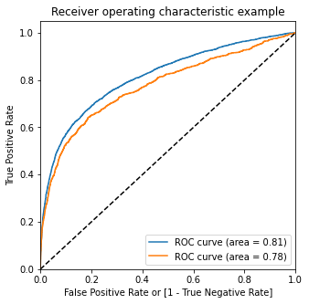

```
Accuracy train:  0.9029490790197793
Accuracy test:  0.8996795183063028
```

```python
# Predicción y cálculo del accuracy del modelo neuronal
# 1. Predicción del modelo
y_train_pred_nn, y_train_pred_nn_prob, y_test_pred_nn, y_test_pred_nn_prob = \
                                    prediction_model(nn_grid, x_train, y_train, x_test, y_test)
# 2. Curva ROC
draw_roc(y_train, y_train_pred_nn_prob, y_test, y_test_pred_nn_prob)
# 3. Se imprime accuracy train/test
print("Accuracy train: ", accuracy_score(y_train, y_train_pred_nn))
print("Accuracy test: ", accuracy_score(y_test, y_test_pred_nn))
```

#### 8.3 Algoritmo Knn

Knn es un algoritmo basado en instancia supervisado donde busca las observaciones más cercanas para intentar predecir. Ventajas:

- Sencillo de implementar Inconveniente:
- Consume muchos recursos: memoria porque utiliza todo el dataset y procesamiento de CPU.

  Se basa en estos principios:
  1. Calcula la distancia del nuevo item con respecto al dataset de entrenamiento
  2. Selecciona los k elementos más cercanos o con menor distancia
  3. realiza una votación de la mayoría.

  Para desempate es importante elegir un valor impar de k y un valor k alto no implica mejor respuesta. Y para el cálculo de la distancia, se suele emplear la distancia Euclidiana.

```python
# Algoritmo Knn K-nearest neighbor
# Calcula las distancias teniendo en cuenta las k features más cercanas.

# 1. Se importa la librería propia auxiliar par el preprocesado de datos
import import_ipynb
import functions

# 2. Se imprime librería split train, test
# y otras: librería del modelo KNeighborsClassifier, numpy y metrics
from sklearn.model_selection import train_test_split
from sklearn.neighbors import KNeighborsClassifier
import numpy as np
from sklearn import metrics

# 3. Preprocesado del dataset
rename=True
df2 =transform(df_ref,rename)
y = df2['deposit_n']
x = df2.drop('deposit_n', axis = 1)

# 4. Split del conjunto de datos en train/test
x_train,x_test,y_train,y_test = train_test_split(x,y, random_state=42)

# 5. Para cada valor de k  del rango, se invoca al modelo para entrenarlo y predecirlo
# Se obtiene un array con los valores de error rate y accuracy.
error_rate = []
acc = []
for i in range(1,40):
     knn = KNeighborsClassifier(n_neighbors=i)
     knn.fit(x_train, y_train)
     pred_i = knn.predict(x_test)
     error_rate.append(np.mean(pred_i != y_test))
     acc.append(metrics.accuracy_score(y_test, pred_i))
```

```
Minimum error:- 0.10119452267650772 at K = 33
```

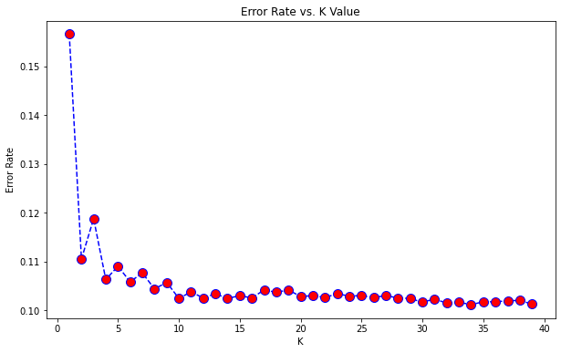

```python
# Visualizacion del tuneado de parámetros en knn model

# 1. Se importa la librería pyplot par vissualizar el tuneado de parámetros.
import matplotlib.pyplot as plt
# 2. Dimensión del ploteado.
plt.figure(figsize=(10,6))
# 3. Se plotear el array Error rate y etiquetado.
plt.plot(range(1,40),error_rate,color='blue', linestyle='dashed',
         marker='o',markerfacecolor='red', markersize=10)
plt.title('Error Rate vs. K Value')
plt.xlabel('K')
plt.ylabel('Error Rate')
# 4. Se imprime el mínimo Error rate y la k correspondiente.
print("Minimum error:-",min(error_rate),"at K =",error_rate.index(min(error_rate)))
```

```
Maximum accuracy:- 0.8988054773234923 at K = 33
```

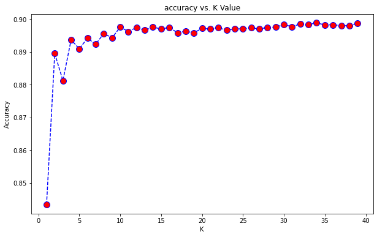

```python
# Se visualiza el accuracy
# 1. Dimensión del ploteado
plt.figure(figsize=(10,6))
# 2. PLoteado del array accuracy en función de k y etiquetado
plt.plot(range(1,40),acc,color = 'blue',linestyle='dashed',
         marker='o',markerfacecolor='red', markersize=10)
plt.title('accuracy vs. K Value')
plt.xlabel('K')
plt.ylabel('Accuracy')
s=pd.Series(acc)
# 3. Se imprime el máximo accuracy y la k correspondiente.
print("Maximum accuracy:-",s.max(),"at K =",acc.index(s.max()))
```

## 9. Tecnicas Oversampling

Técnica Over-sampling basado en los k-nearest vecinos para la creación de más casos de la clase minorista. Se observa que se obtiene un mayor accuracy de 0.95 con respecto a 0.9 para el modelo de regresion logística. Puede ser una alternativa a consisderar de cara a futuro pero de momento se descarta porque es una alteración de los datos de entrada, ya que se pasa de 41188 datos a 73096.

A continuación, se observa su implementación mediante la utilidad SMOTE de paquete imblearn.over_sampling El resto es la misma implementación que se hizo para regresión logística con su mmisma interpretación de resultados obtenidos.

```
Tamaño original  41188
Tamaño remuestreado 73096
              precision    recall  f1-score   support

          no       0.97      0.93      0.95      9550
         yes       0.93      0.97      0.95      8724

    accuracy                           0.95     18274
   macro avg       0.95      0.95      0.95     18274
weighted avg       0.95      0.95      0.95     18274
```

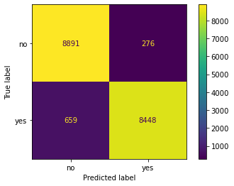

```python
# 1. Se importa nuestra librería de funciones auxiliares
import import_ipynb
import functions
%run functions.ipynb

# 2. Dependencia para el split train,test
from sklearn.model_selection import train_test_split

# 3. Librería panda para lectura del dataframe
import pandas as pd

# 4. Librerías para normalizacion de datos y métricas en general
from sklearn.preprocessing import StandardScaler
from sklearn import metrics

# 5. Librería para el Modelo de regresion logística
# Así como dependencias para obtención de informe de clasificación
from sklearn.linear_model import LogisticRegression
from sklearn.metrics import classification_report,confusion_matrix,ConfusionMatrixDisplay

# 6.Librería para over-sampling
from imblearn.over_sampling import SMOTE
#from imblearn.combine import SMOTETomek

# 7. Lectura del fataframe
url='bank-additional-full.csv'
df_ref = pd.read_csv(url,sep=";")

# 8. Procesado básico del dataframe
x=df_ref.drop(['y'],axis=1)
x=pd.get_dummies(x)
y=df_ref['y']


# 9. Instanciación del objeto Smote
smote = SMOTE()
# Otra alternativa de over-sampling mediante librería SMOTETomek
#smt = SMOTETomek()
#X_smt, y_smt = smt.fit_resample(x_train, y_train)

# 10. Obtencion de mas muestras para el equilibrado
print('Tamaño original ', len(x))
x, y = smote.fit_resample(x, y)
print('Tamaño remuestreado', len(x))

# 11. Split en test y train
x_train,x_test,y_train,y_test = train_test_split(x,y, random_state=42)


# 12. Escalado de los datos
scaler=StandardScaler()
x_train=scaler.fit_transform(x_train)
x_test=scaler.fit_transform(x_test)

# 13. Modelling como regresión logística

logreg = LogisticRegression(solver='liblinear', random_state = 100)
logreg = logreg.fit(x_train, y_train)

# 14. Obtención del informe de clasificación
report(logreg)
```

#### Análisis de Métricas

Precision: 97% de tasa de acierto para la no contratacion frente a un 93% de contratacion de deposito.

Recall o ratio verdaderos positivos o sensibilidad: 93 % para el no y 97% para el si.

Además se obtiene la matriz de consfusión con el detalle de los casos postitivos/negativos acertados y los falsos positivos/negativos.

## 10. Produccion Flask

Para poner en producción el modelo, se debe cargar el modelo seleccionado que se grabó con extensión pkl. Mediante la libería Flask se genera un servidor que está a la escucha en una IP y puerto. En este caso localhost y puerto 5000. Cuando se recibe una petición o solicitud de depósito de un nuevo cliente, se consumen los recursos a través de las API´s implementadas. Dichos recursos se definen con la palabra clave @app.route, en el cual se identifica el recurso y los métodos a implementar. En nuestro caso, se ha definido dos métodos GET y POST donde se rellena un formulario web y se predice sobre los datos introducidos, mandando una predicción en formato json donde se dice si se le concede el depóstino o no.

Para la recogida de los datos del formulario se ha empleado código html (form1.html) donde se define la página web con todos los campos a recoger y sus tipos. Además se le asocia la guia de estilo style_form1.css donde se diseña el aspecto físico de la propia página web. Además se le asocia el javascript form1.js para que el nombre descriptivo de cada campo del formulario se sitúe arriba cuando haya contenido o el foco esté en el propio formulario.

Por último para darle una acceso externo al servicio web local implementado, se lanza el ejecutable ngrok de tal manera que mediante un URL externa redirige todo su tráfico a la URL local. Para ello hay que ejecutar desde el cmd de windows el siguiente comando: ngrok.exe http 5000.

```python
# Servicio que realiza predicción sobre una petición
# mediante formulario
# 1. Se importa nuestra librería de funciones auxiliares
import import_ipynb
import functions
%run functions.ipynb

# 2. Se importan todas las librerías necesarias para implementar dicho servicio
from flask import Flask, request, jsonify, render_template
import joblib # Se utiliza joblib para leer el modelo pre-entrenado
import pandas as pd

# Ademas se carga en memoria el dataframe original.
# Es importante que se realimente para su actualización.
# Por último se visualiza para comprobar su correcta carga en memoria

url='bank-additional-full.csv'
df_ref = pd.read_csv(url,sep=";")

# 3. Se crea la instancia de Flask
app = Flask(__name__)

# 4. Se abre el archivo que contiene el modelo candidato grading boosting
#MODEL_BANK_TEST = joblib.load('new_model_try2.pkl')
MODEL_BANK_TEST = joblib.load('model_gb_grid.pkl')


# 5. Se crean las etiquetas con las cuales se clasificaran nuevos datos
# Sabemos que se corresponde con la denegación o concesión del depósito.

MODEL_LABELS_BANK =['no','yes']
"""
El método predict sera el encargado de clasificar y dar una respuesta
a cualquier IP que le envie una petición.
"""
# 6. Recurso que sólo captura los datos del formulario.
@app.route('/form1')
def form1():
    return render_template('form1.html')

# 7. Recurso que genera una predicción mediante la recogida de datos de entrada
# a través de un formulario.
@app.route('/form1+', methods=['POST','GET'])
def form1_():
    if request.method == "GET":
        return render_template('form1.html')
    # 8. Obtiene los datos del formulario en modo diccionario mediante el método request
    elif request.method== 'POST':
        data = request.form.to_dict()
        # 9. Se visualiza el diccionario de entrada. Se activa en modo debug
        #print(data)
        #print(data.keys())
        #print(data.values())

        # 10. Conversión de datos adecuada de las variables numéricas
        data['age']= int(data['age'])
        data['campaign'] = int(data['campaign'])
        data['pdays'] = int(data['pdays'])
        data['previous'] = int(data['previous'])
        data['emp.var.rate'] = float(data['emp.var.rate'])
        data['cons.price.idx']= float(data['cons.price.idx'])
        data['cons.conf.idx']= float(data['cons.conf.idx'])
        data['euribor3m'] = float(data['euribor3m'])
        data['nr.employed'] = float(data['nr.employed'])

        # 11. Se formatea adecuadamente el nuevo registro para añadirlo al dataframe original
        data2={'contact': data['contact'], 'month': data['month'], 'day_of_week': data['day_of_week'],
        'campaign': data['campaign'], 'pdays': data['pdays'], 'previous': data['previous'],'poutcome': data['poutcome'],
        'age': data['age'], 'job': data['job'],'marital': data['marital'], 'education': data['education'],
        'default': data['default'], 'housing': data['housing'],'loan': data['loan'],
        'emp.var.rate': data['emp.var.rate'], 'cons.price.idx': data['cons.price.idx'],
        'cons.conf.idx':data['cons.conf.idx'] ,'euribor3m': data['euribor3m'], 'nr.employed': data['nr.employed']}

        # 12. Se añade nuevo dato al dataframe original
        df1= df_ref.append(data2,ignore_index=True)

        # 13. Se procesa adecuadamente para alimentar al modelo ya entrenado
        rename=True
        df2 =transform(df1,rename)
        # 14. Se obtiene el último registro correspondiente del formulario ya entrenado.
        df2 = df2.drop('deposit_n', axis = 1)
        x1=df2.tail(1)

        # 15. Se visualiza el resgistro procesado junto con sus columnas
        print(x1)
        x1.columns

        # 16. Se realiza dicha predicción.
        label_index = MODEL_BANK_TEST.predict(x1)

        """
        La variable label contendra el resultado de la clasificación.
        """
        # 17. Se obtiene la etiqueta de dicha predicción
        label = MODEL_LABELS_BANK[label_index[0]]

        # 18. Se crea y se envía la respuesta al cliente
        return jsonify(status='Predicción Completada', prediccion=label)
        #return "Formulario recibido"
    else:
        return "Método no aceptado"

# 19. Recurso de página no encontrada
@app.errorhandler(404)
def page_not_found(error):
    return render_template('page_not_found.html'),404

# 20. Se inicia y se pone a la escucha el servidor.
if __name__ == '__main__':

    app.run(debug=False)
```

## 11. Otras predicciones

En el siguiente bloque se implementa un modelo de regresión logística donde se ha definido una función auxiliar propia en el cual se predice fijando el umbral internamente a 0.3 meiante la función: (model.predict_proba(x_test)[:,1] >=0.3) Con un eso se consigue por tanto detectar más casos positivos: para negocio puede ser importante porque me imagino que la idea es centrarse en el conjunto de la población con mayor probabilidad o tendencia a subscribirse a un depósito.

```
Logistic Regression: 0.900521 (0.004396)
              precision    recall  f1-score   support

       False       0.96      0.92      0.94      9471
        True       0.36      0.50      0.42       826

    accuracy                           0.89     10297
   macro avg       0.66      0.71      0.68     10297
weighted avg       0.91      0.89      0.90     10297
```

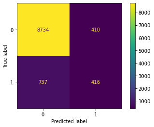

```python
# Nuevas predcciones bajando el umbral a 0.3
# 1. Se importa nuestra librería de funciones auxiliares
import import_ipynb

%run functions.ipynb
# 2. Se importa el modelo de regresión logística
from sklearn.linear_model import LogisticRegression
# 3. Se importa librerías necesarias para entrenamiento, predicción e informes de clasificación.
from sklearn import model_selection

from sklearn.metrics import plot_confusion_matrix,classification_report,plot_precision_recall_curve,plot_roc_curve
from sklearn.metrics import confusion_matrix, ConfusionMatrixDisplay
from sklearn.metrics import accuracy_score, confusion_matrix

from sklearn.model_selection import KFold, StratifiedKFold
from sklearn.model_selection import cross_val_score
from sklearn.model_selection import GridSearchCV
from sklearn import metrics
import matplotlib.pyplot as plt
import pandas as pd
# split train, test
from sklearn.model_selection import train_test_split
#from sklearn.metrics import precision_score

# 3. Lectura datos, preprocesado y preparación de datos
url='bank-additional-full.csv'
df_ref = pd.read_csv(url,sep=";")
rename=True
df2 =transform(df_ref,rename)
y = df2['deposit_n']
x = df2.drop('deposit_n', axis = 1)

# 4. split datos de entrenamiento y test
x_train,x_test,y_train,y_test = train_test_split(x,y, random_state=42)
# 5. Se invoca al modelo.
logreg_threshold = LogisticRegression(solver='liblinear', random_state = 100, max_iter = 1000)

# 6. Entrenamiento del modelo
name='Logistic Regression'
kfold = model_selection.KFold(n_splits=10, shuffle = True, random_state=100)
cv_results = model_selection.cross_val_score(logreg_threshold, x_train, y_train, cv=kfold, scoring='accuracy')
msg = "%s: %f (%f)" % (name, cv_results.mean(), cv_results.std())
print(msg)
logreg_threshold.fit(x_train, y_train)

# 7. Predicción con el nuevo threshold en 0.3 llamando a función propia auxiliar report_threshold
report_threshold(logreg_threshold)
```

Otra opción interesante podría ser obtener la probabilidad de que un determinado cliente se subscriba. Mediante el método predict_proba se obtiene el array de probabilidades. A modo de ejemplo se visualiza la probabilidad de los dos primeros datos visualizados y detallados en el último bloque. La matriz de probabilidades consiste en la probabilidad del no y la probabilidad del si para cada entrada de datos

```python
# Visualización de probabilidades
# 1. Se obtiene las probabilidades del conjunto de test
predi=logreg_threshold.predict_proba(x_test)

# 2. Se imprime la matriz de los dos primeros clientes de test.
print(predi[:2])
#for i in range(len(Xnew)):
 #   print("X=%s, Predicted=%s" % (Xnew[i], ynew[i]))
```

```
[[0.89997877 0.10002123]
 [0.96940248 0.03059752]]
```

```python
# Visualización de los dos primeros clientes de test de los que se ha predicho la probabilidad de subscripción
x_test.head(2)
```

|  | age | n_contacts | days_from_last_campaign | n_past_contacts | ipc | icc | euribor3m | debts_n | mortage_n | loan_n | ... | education_basic.9y | education_high.school | education_illiterate | education_professional.course | education_university.degree | education_unknown | day_of_week_mon | day_of_week_thu | day_of_week_tue | day_of_week_wed |
| --- | --- | --- | --- | --- | --- | --- | --- | --- | --- | --- | --- | --- | --- | --- | --- | --- | --- | --- | --- | --- | --- |
| 32884 | 1.628993 | -0.565922 | 0.195414 | 1.671136 | -1.179380 | -1.231034 | -1.338939 | 0 | 0 | 2 | ... | 0 | 1 | 0 | 0 | 0 | 0 | 1 | 0 | 0 | 0 |
| 3169 | 1.437075 | -0.204909 | 0.195414 | -0.349494 | 0.722722 | 0.886447 | 0.714190 | 1 | 2 | 0 | ... | 0 | 0 | 0 | 0 | 0 | 1 | 0 | 1 | 0 | 0 |

2 rows × 38 columns

## 12. Ambitos de mejora

A continuación se muestran algunos ámbitos de mejora por donde se podría continuar con este proyecto:

1. Desarrollo de una plataforma o MLOPs donde se pueda automatizar el aprendizaje, realimentar nuevos datos y se mantenga la explotación.
2. Se podría investigar en un mejor preprocesado para aquellos modelos que son más sensibles a ello para ver si hay ámbito de mejora. Por ejemplo creacion de nuevas variables que puedan aportar valor a la predicción, mejor imputación o codificación de las variables ....
3. Implementación de una base de datos donde se actualicen nuevos datos y se actualicen los modelos in-situ
4. Para alcanzar mayor eficiencia en el modelado, se podría buscar una plataforma en la nube con procesadores potentes donde se pueda incluir mayores opciones de tuneado para observar los grados de mejora o google colab con la opcion GPU activada.
5. Estudiar la posibilidad de diferentes técnicas de desbalanceo en entornos desarrollo para observar si se obtienen buenas métricas.

   En función de los logros obtenidos, se podría proponer nuevas necesidades del proyecto de cara a futuro. Este proyecto está en una fase inicial, donde se ha realizado un estudio con un pequeño entorno de producción: existe un boraador en google colab: https://colab.research.google.com/drive/1m7xPfJjf9evEKV_1VTMeZVDlfH22OdII?hl=es#scrollTo=_arUhB1yE7v3 Se podría continuar con los àmbitos de mejora propuetos para seguir con su evolución.